# Importing US incarceration and execution data

Michelle Tschida

March 2015

# Crime Data Load 1

This set of code imports and cleans the crime data.

# Downloading state information from the US Census Quick facts and the state data set from R.

This will be general demographic data to consider in our analysis.

The US Census Quick Facts can be found @ http://quickfacts.census.gov/qfd/download_data.html.

The state data sets comes with R and is part of the data sets package.

> Some data sets from this piece of code are:  
> * qf_dd, #quick facts data dictionary  
> * qf_fips, # quick facts state and county fips  
> * st_fips, #State FIPS CODES  
> * cns_qf , #US Census Quick Facts  
> * cns_qf_state #US Census Quick Facts just for a state  
> * StateDemo, #state info from the state() data set

```r
#All Census data from this website:
#http://quickfacts.census.gov/qfd/download_data.html

# US Census Quick Facts data dictionary
url_dd <- "http://quickfacts.census.gov/qfd/download/DataDict.txt"

#reading in a file with fixed widths and headders
qf_dd <- read.fwf(url_dd, widths=c(10,88,5,4,14,8,9,10) ,strip.white=TRUE,
                  header=FALSE, skip=2,
                  col.names=c("Data_Item","Item_Description","Unit", "Decimal","US_Total","Minimum",
                 "Maximum","Source") ) #2010 Census Data Dictionary


#US Census FISP Codes at the state and county level.

url_fisp <- "http://quickfacts.census.gov/qfd/download/FIPS_CountyName.txt"
# FIPS Codes

qf_fips<- read.fwf(url_fisp,header=FALSE, skip=1,
              widths=c(6,50) ,strip.white=TRUE, col.names=c("FIPS", "County.Name"))

# http://stackoverflow.com/questions/9934856/removing-non-ascii-characters-from-data-files
qf_fips$County.Name <- iconv(qf_fips$County.Name, "latin1", "ASCII", sub="")



sn <- c(state.name,"District of Columbia","District of Columbia, DC")

qf_fips$state.name.lower <- tolower(qf_fips$County.Name)

lower_c <- as.data.frame(c(as.data.frame(sn),as.data.frame(tolower(sn))))

names(lower_c)<- c("state.name","state.name.lower")

#State FIPS CODES
st_fips <- merge(x=qf_fips,y=lower_c, by.x="state.name.lower", by.y="state.name.lower")
names(st_fips$County.Name) <- "state.name.upper"


#Census Quick Facts - for all states and counties

url_qf <- "http://quickfacts.census.gov/qfd/download/DataSet.txt"
# US Census quickfacts.  3195 rows, one for the U.S., one for each state, one for each county.

cns_qf <- read.csv(file=url_qf)

#Inner join to get Census Quick Facts for State
cns_qf_state  <- merge(x=cns_qf,y=st_fips, by.x="fips", by.y="FIPS")


#State Information
state_info <- as.data.frame(cbind(state.name,as.character(state.division),
                                  as.character(state.region), state.abb, state.x77))

names(state_info)[names(state_info)=="Life Exp"]  <- "LifeExp"
names(state_info)[names(state_info)=="HS Grad"]  <- "HSGrad"

state_info$Population<- as.numeric(state_info$Population)
state_info$Income<- as.numeric(state_info$Income)
state_info$Illiteracy<- as.numeric(state_info$Illiteracy )
state_info$LifeExp<- as.numeric(state_info$LifeExp )
state_info$Murder<- as.numeric(state_info$Murder)
state_info$HSGrad<- as.numeric(state_info$HSGrad)
state_info$Frost<- as.numeric(state_info$Frost )
state_info$Area <- as.numeric(state_info$Area)

names(state_info)[names(state_info)=="V2"] <- "state.division"
names(state_info)[names(state_info)=="V3"] <-"state.region"

# state_info #state info from the state() data set


#mergine state info from R data files withfips
st_info_fips <- merge(st_fips,state_info,all=TRUE)


# merging state info and fips with censue information
names(cns_qf_state)[names(cns_qf_state)=="fips"]<-"FIPS"

StateDemo <- merge(st_info_fips ,cns_qf_state,all=TRUE)
names(StateDemo)[names(StateDemo)=="V2"] <- "state.division"
names(StateDemo )[names(StateDemo )=="V3"] <-"state.region"
names(StateDemo)
```

```
##  [1] "state.name"       "state.name.lower" "FIPS"
##  [4] "County.Name"      "state.division"   "state.region"
##  [7] "state.abb"        "Population"       "Income"
## [10] "Illiteracy"       "LifeExp"          "Murder"
## [13] "HSGrad"           "Frost"            "Area"
## [16] "PST045214"        "PST045213"        "PST040210"
## [19] "PST120214"        "PST120213"        "POP010210"
## [22] "AGE135213"        "AGE295213"        "AGE775213"
## [25] "SEX255213"        "RHI125213"        "RHI225213"
## [28] "RHI325213"        "RHI425213"        "RHI525213"
## [31] "RHI625213"        "RHI725213"        "RHI825213"
## [34] "POP715213"        "POP645213"        "POP815213"
## [37] "EDU635213"        "EDU685213"        "VET605213"
## [40] "LFE305213"        "HSG010213"        "HSG445213"
## [43] "HSG096213"        "HSG495213"        "HSD410213"
## [46] "HSD310213"        "INC910213"        "INC110213"
## [49] "PVY020213"        "BZA010213"        "BZA110213"
## [52] "BZA115213"        "NES010212"        "SBO001207"
## [55] "SBO315207"        "SBO115207"        "SBO215207"
## [58] "SBO515207"        "SBO415207"        "SBO015207"
## [61] "MAN450207"        "WTN220207"        "RTN130207"
## [64] "RTN131207"        "AFN120207"        "BPS030213"
## [67] "LND110210"        "POP060210"
```

# Importing total yearly executions for the US and by state for years 1977 to 2014.

This was obtained from http://www.bjs.gov/content/dtdata.cfm#State/

```r
#'@title ExecData
#'@description A function to import and clean US capitol punishment
#'@description  Importing and cleaning US capitol punishment total by year and state.
#'@details This function melts the years into one column and makes a column for 'executions'.  This gives the total number of prisoners executed under civil authority in the United States, by year, region, and jurisdiction, 1977-2014.
#'@details Executions is the total number of executions for that year
#'
#' The data can be found at  "http://www.bjs.gov/content/data/exest.csv".
#'@param f1 is the file to be read.
#'@param skip1 is the number of rows to skip
#'@param nrows1 is the number of rows to read
#'@param ... any additional field
#'@return returns a data frame
#'@author Michelle Tschida
#'@export

ExecData <- function(f1= "http://www.bjs.gov/content/data/exest.csv", skip1=10, nrows1=64,...){


#reading the csv file from the web
exe <- read.csv(file=f1 , skip=skip1, nrows=nrows1, sep=",",check.names=TRUE,
                header=TRUE, blank.lines.skip=TRUE,strip.white=TRUE)

# A list of all of the states in the state.name file plus District of columbia
StateList <- c(state.name,"District of Columbia")

names(exe)[names(exe)=="Region.and.jurisdiction"] <- "Jurisdiction" #naming the 1st column "Jurisdiction"

exe$Jurisdiction <- gsub(x=exe$Jurisdiction, pattern="Dist. of Col.",replacement="District of Columbia")
# replacing 'Dist. of col. with District of Columbia

exe <- exe[-(nrow(exe)),] # removing the last 2 lines
exe <- exe[-(nrow(exe)),]  # removing the last 2 lines
exe <- exe[!(is.na(exe$X1977)),] #removing blank lines
exe$Total <-as.numeric(gsub(",","", exe$Total)) # making total executions numeric


# lableing descriptions to be state, US or region.
exe$desc[exe$Jurisdiction %in% c("U.S. total","Federal","State")] <- "US"
exe$desc[exe$Jurisdiction %in% c("Northeast","Midwest", "South","West")] <- "region"
exe$desc[which(exe$Jurisdiction %in% StateList)] <- "state"

#Reshaping the data
exe1 <- reshape2::melt(data=exe,id=c("Jurisdiction","desc"),variable.name="year",value.name= "executions")

#making years more readable
exe1$year <- gsub(pattern="X",replacement="",exe1$year)
exe1$year<-gsub(pattern="Total",replacement="1977 - 2014",exe1$year)
  # Changing Total to the years involved just as a reminder

exe1$executions <- as.numeric(exe1$executions) #making executions numeric

out<- exe1

return(out)

}
# end of exection data function()


exe <- ExecData()

# Executions by year
# Splitting up the yearly data into state  and US
ExecByYear <-exe %>% filter(year %in% (1977:2014))     %>%
      filter(desc=="state" | Jurisdiction=="U.S. total" )
ExecByYear$year <- as.numeric(ExecByYear$year)

 ExecByYear_us  <-ExecByYear   %>% filter(Jurisdiction=="U.S. total")
ExecByYear_state <-ExecByYear %>% filter(desc=="state")


# Total Executions - years rolled up for state and US

ExecTotal <- exe %>% filter((year=="1977 - 2014"))   %>% filter(desc=="state"  | Jurisdiction=="U.S. total")
 ExecTotal_us  <- exe %>% filter((year=="1977 - 2014"))   %>% filter(Jurisdiction=="U.S. total")
 ExecTotal_state  <- exe %>% filter((year=="1977 - 2014"))   %>% filter(desc=="state")
```

### Exploring execution data.

Texas has the most executions. Many states have 0 executions. Executions in the US peaked around the year 2000.

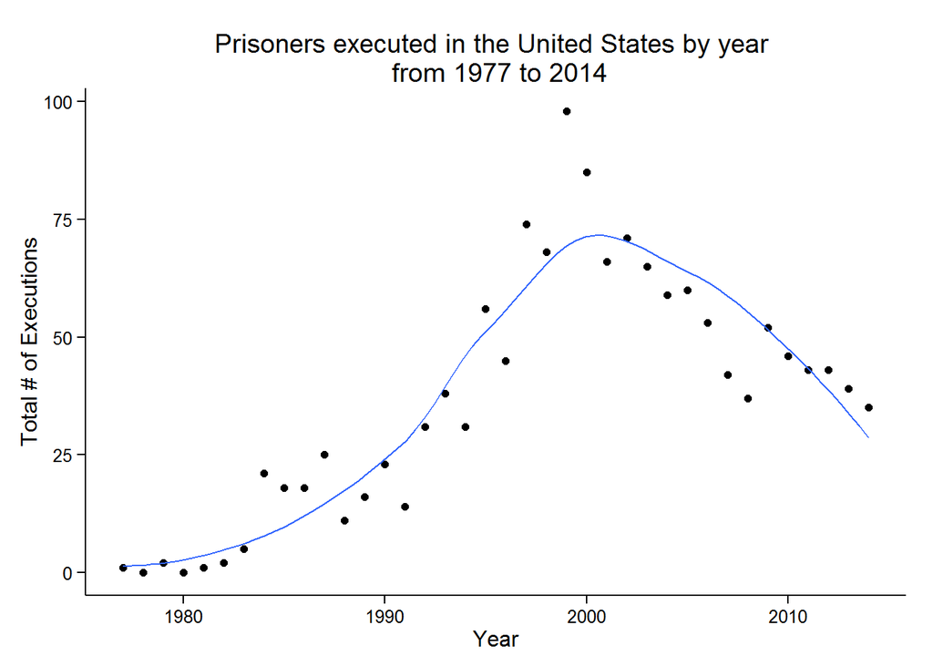

```r
#install.packages("ggplot2")
library(ggplot2)

#par(mfrow=c(2,2))


 ggplot2::ggplot(data=ExecByYear_us, aes(x=year, y=executions) )+
 ggplot2::theme_bw() +
  ggplot2::theme(panel.grid.major = element_blank(),
        panel.grid.minor = element_blank(),
        panel.border = element_blank(),
        axis.line = element_line(colour = "black")
        ) +
    ggplot2::geom_point()+
  ggplot2::stat_smooth(se=FALSE, method="loess") +
  ggplot2::xlab("Year") +
  ggplot2::ylab("Total # of Executions")+
  ggplot2::ggtitle("Prisoners executed in the United States by year \n from 1977 to 2014")
```

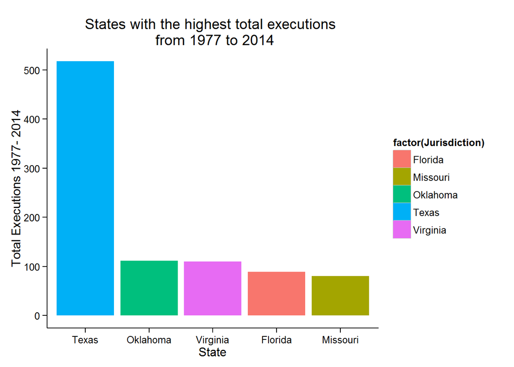

```r
# warnings()
# to plot by state
#ggplot(data=ExecByYear_state[ExecTotal_state$executions>=75,], aes(x=year, y=executions, group=Jurisdiction, color=Jurisdiction) )  +



ggplot2::ggplot(data=ExecByYear_state[ExecTotal_state$executions >=75,], aes(x=Jurisdiction, y=executions,
      fill=factor(Jurisdiction) ))  +
 ggplot2::theme_bw() +
  ggplot2::geom_bar(stat="identity",aes(x=reorder(Jurisdiction,desc(executions))))+
  ggplot2::theme(panel.grid.major = element_blank(),
        panel.grid.minor = element_blank(),
        panel.border = element_blank(),
        axis.line = element_line(colour = "black")
        )+
  ggplot2::scale_color_manual(values = wesanderson::wes_palette("Rushmore")) +
  ggplot2::xlab("State") +
  ggplot2::ylab("Total Executions 1977- 2014") +
  ggplot2::ggtitle("States with the highest total executions \n from 1977 to 2014")
```

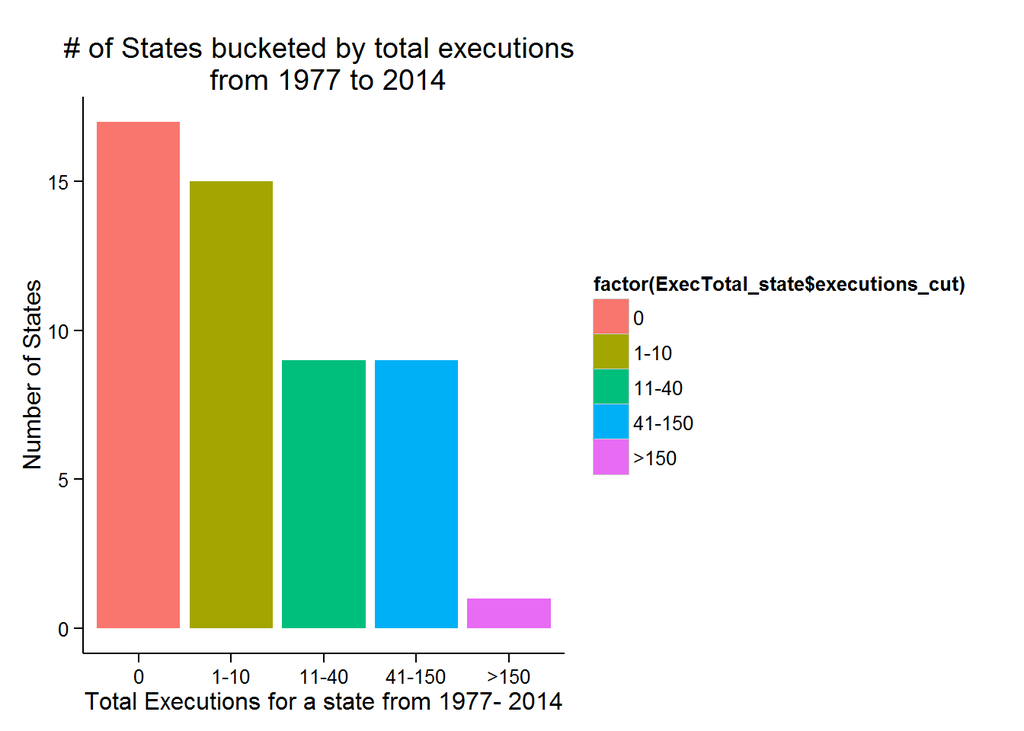

```r
#table(ExecTotal_state$executions)

#str(ExecTotal_state$executions)

ExecTotal_state$executions_cut <- cut(ExecTotal_state$executions,
          breaks=c(-Inf,0,10,40,150,Inf),
          labels=c("0","1-10","11-40","41-150", ">150" ))

#table(ExecTotal_state$executions_cut)

ggplot2::ggplot(data=ExecTotal_state, aes(x=ExecTotal_state$executions_cut,
                                 fill=factor(ExecTotal_state$executions_cut)) )  +
  ggplot2::theme_bw() +
   ggplot2::geom_bar(stat="bin")+

  ggplot2::theme(panel.grid.major = element_blank(),
        panel.grid.minor = element_blank(),
        panel.border = element_blank(),
        axis.line = element_line(colour = "black")
        )+
  ggplot2::scale_color_manual(values = wesanderson::wes_palette("Rushmore")) +
  ggplot2::xlab("Total Executions for a state from 1977- 2014") +
  ggplot2::ylab("Number of States") +
  ggplot2::ggtitle("# of States bucketed by total executions \n from 1977 to 2014")
```

```r
ExecTotal_state$executions_cut <- NULL
#par(mfrow=c(1,1))
```

# Importing incarceration rates by state 1978 - 2013.

These stats give incarcerations per 100,000 residents.

This data can be found @ http://www.bjs.gov/index.cfm?ty=nps under the tab ‘Quick Tables’.

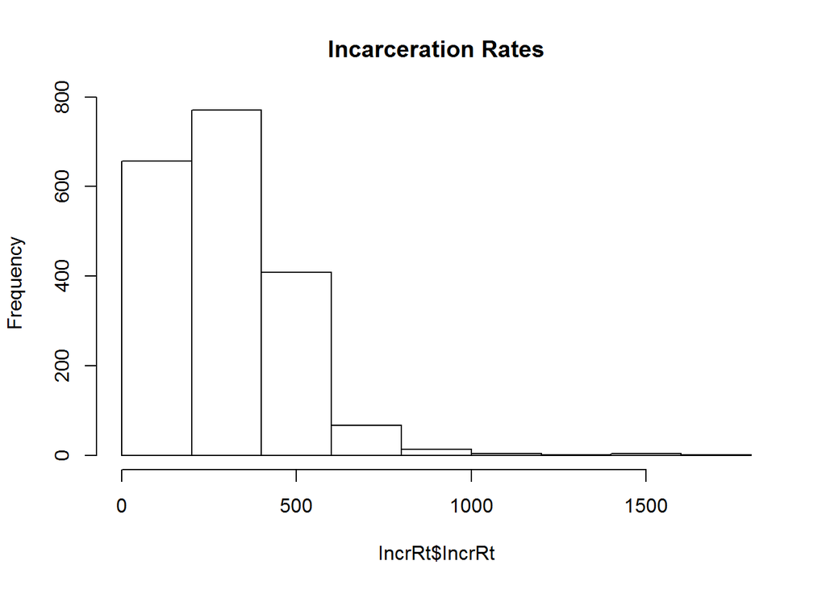

```r
#'@title A function to import and clean incarceration rates by year and state.
#'@description Incarceration rates are per 100,000 people by state.
#' This can be found at http://www.bjs.gov/index.cfm?ty=nps under the tab 'Quick Tables'.
#'@param file1, sheetIndex1, startRow1 and endRow1 are all parameters (with a 1 attached) from the read.xlsx package
#'@author Michelle Tschida
#'@export

IncerData <- function(file1 = "http://www.bjs.gov/nps/resources/documents/QT_imp%20rate_tot.xlsx",
    sheetIndex1=1, startRow1=10, endRow1 = 64,... ){

# Importing incarceration data

td <- tempdir()  # create a temporary directory.  irt stands for incarceration rate.

irt = tempfile(tmpdir=td, fileext=".xlsx") # create the placeholder file

download.file(url=file1, destfile=irt, mode="wb") # download into the placeholder file

 inc <- xlsx::read.xlsx(file=irt, sheetIndex=sheetIndex1,startRow=startRow1, endRow=endRow1)  # reading in the data

# Some data Cleaining

  names(inc)[names(inc)=="NA."] <- "state"


  # moving the Jurisdiction and state names into one column
  inc$Jurisdiction1[is.na(inc$Jurisdiction)] <-  as.character(inc$state[is.na(inc$Jurisdiction)])

  inc$Jurisdiction1[!is.na(inc$Jurisdiction)] <-  as.character(inc$Jurisdiction[!is.na(inc$Jurisdiction)])

  # Adding a state or US, which is the total, to the descrption description
  inc$desc[is.na(inc$Jurisdiction)] <-  "state"
  inc$desc[!is.na(inc$Jurisdiction)] <- "US"



  # cleaing up variables and getting rid of temp variables
  inc$Jurisdiction <-  inc$Jurisdiction1
  inc$state <- NULL
  inc$Jurisdiction1 <- NULL

  #getting special characters out of Jurisdiction '|' means or
  inc$Jurisdiction <- gsub(inc$Jurisdiction,pattern="/a|/b|/c|/d|/e",replacement="")



  # getting rid of the -- which stands for missing
  inc <- as.data.frame(sapply(inc,gsub,pattern="--",replacement=NA))

  # there must be a way to do this in a loop... :)

  inc$X1978<-as.numeric(as.character(inc$X1978))
  inc$X1979<-as.numeric(as.character(inc$X1979))
  inc$X1980<-as.numeric(as.character(inc$X1980))
  inc$X1981<-as.numeric(as.character(inc$X1981))
  inc$X1982<-as.numeric(as.character(inc$X1982))
  inc$X1983<-as.numeric(as.character(inc$X1983))
  inc$X1984<-as.numeric(as.character(inc$X1984))
  inc$X1985<-as.numeric(as.character(inc$X1985))
  inc$X1986<-as.numeric(as.character(inc$X1986))
  inc$X1987<-as.numeric(as.character(inc$X1987))
  inc$X1988<-as.numeric(as.character(inc$X1988))
  inc$X1989<-as.numeric(as.character(inc$X1989))
  inc$X1990<-as.numeric(as.character(inc$X1990))
  inc$X1991<-as.numeric(as.character(inc$X1991))
  inc$X1992<-as.numeric(as.character(inc$X1992))
  inc$X1993<-as.numeric(as.character(inc$X1993))
  inc$X1994<-as.numeric(as.character(inc$X1994))
  inc$X1995<-as.numeric(as.character(inc$X1995))
  inc$X1996<-as.numeric(as.character(inc$X1996))
  inc$X1997<-as.numeric(as.character(inc$X1997))
  inc$X1998<-as.numeric(as.character(inc$X1998))
  inc$X1999<-as.numeric(as.character(inc$X1999))
  inc$X2000<-as.numeric(as.character(inc$X2000))
  inc$X2001<-as.numeric(as.character(inc$X2001))
  inc$X2002<-as.numeric(as.character(inc$X2002))
  inc$X2003<-as.numeric(as.character(inc$X2003))
  inc$X2004<-as.numeric(as.character(inc$X2004))
  inc$X2005<-as.numeric(as.character(inc$X2005))
  inc$X2006<-as.numeric(as.character(inc$X2006))
  inc$X2007<-as.numeric(as.character(inc$X2007))
  inc$X2008<-as.numeric(as.character(inc$X2008))
  inc$X2009<-as.numeric(as.character(inc$X2009))
  inc$X2010<-as.numeric(as.character(inc$X2010))
  inc$X2011<-as.numeric(as.character(inc$X2011))
  inc$X2012<-as.numeric(as.character(inc$X2012))
  inc$X2013<-as.numeric(as.character(inc$X2013))

  # Re-arrange the data
  inc2 <- reshape2::melt(data=inc,id.vars=c("Jurisdiction","desc"),value.name="IncrRt",variable.name="year")

  inc2$year <- gsub(pattern="X",replacement="",x=inc2$year)  # getting rid of the X in front of year
  inc2$year <- as.numeric(inc2$year) #make year numeric

  out <- inc2
  return(out)
  }


IncrRt <- IncerData()

hist(IncrRt$IncrRt, main="Incarceration Rates")
```

### Exploring incarceration rates

Incarceration rates rose from the 1980’s to the year 20000 and then remained fairly constant.

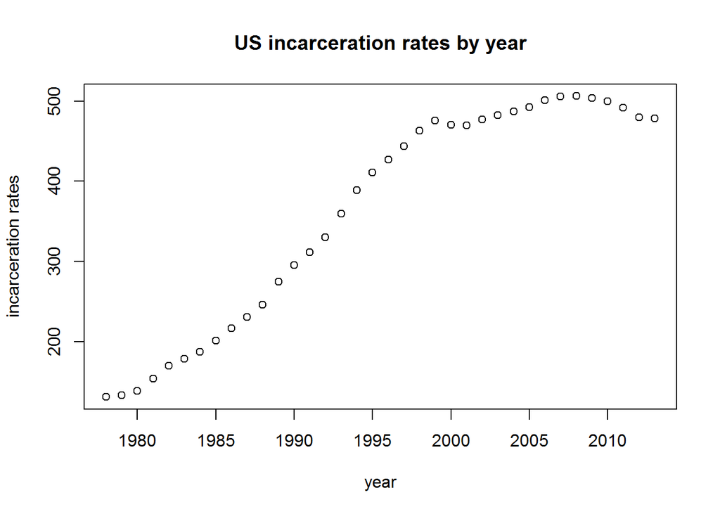

```r
#head(IncrRt)
#str(IncrRt)

#unique(IncrRt$Jurisdiction)

plot(x=IncrRt$year[IncrRt$Jurisdiction=="U.S. total"],
     y=IncrRt$IncrRt[IncrRt$Jurisdiction=="U.S. total"],
     xlab="year",
     ylab="incarceration rates",
     main="US incarceration rates by year")
```

```r
Incr_avg <- aggregate(x=IncrRt$IncrRt, by =list(IncrRt$Jurisdiction), FUN=mean,na.rm=TRUE)
names(Incr_avg)<- c("Jurisdition","AvgIncrRt")

Incr_avg <- Incr_avg[order(Incr_avg$AvgIncrRt),]
```

# Importing estimated crime rates by state and year.

This data can be found by using the tools at http://www.bjs.gov/ucrdata/Search/Crime/State/RunCrimeStatebyState.cfm

```r
# Importing and cleaning estimated crime rates by state and year
#This data can be found by using the tools @ http://www.bjs.gov/ucrdata/Search/Crime/State/RunCrimeStatebyState.cfm
# I downloaded this to my hard drive , cleaned it a bit then imported it.




EstCrime <- read.csv(file="C:/Users/michelle/Dropbox/R class 2/final project/FinalData/CrimeStatByState_mt.csv",
      sep=",",header=TRUE, blank.lines.skip=TRUE,strip.white=TRUE,check.names=TRUE,
     fill=TRUE,colClasses=c("character",rep("numeric",20)))

EstCrime$State <- as.factor(EstCrime$State)

#head(EstCrime,2)
#str(EstCrime)
```

# Combining data sets

Combining Crime Estimate Data to make the CrmYrUS data set. This is Incarceration rates , executions and crime estimates for the TOTAL U.S. by year.

```r
# IncrRt is Incarceration rates by year
# ExecByYear_us is the executions by year for the entire us
# us by year  - Incarceration rates and executions
IE_yr_us <- merge(IncrRt[IncrRt$Jurisdiction=="U.S. total" ,],ExecByYear_us)
IE_yr_us$desc <-NULL
# Adding in crime estimates by year, which is the EstCrime data set
#EstCrime  # Estimated Crime by State by year.
temp <- EstCrime[EstCrime$State=="U.S. total",c(1:3,13:21)]
names(temp)[names(temp)=="State"] <-"Jurisdiction"
names(temp)[names(temp)=="Year"] <-"year"


#Inner join, of Incarceration rates, execution totals and crime estimate, so some years will be sacrificed
#### Final Data Set :  Incarceration rates , executions and crime estimates for the total us by year
CrmYrUS <- merge(IE_yr_us,temp)
```

Combining Crime Estimate Data to make the CrmYrSt data set. This is incarceration rates , executions and crime estimates by STATE BY YEAR.

```r
# Incarceration rates and executions by year by state, inner join
IE_yr_st <- merge(IncrRt[IncrRt$desc=="state" ,],ExecByYear_state)
IE_yr_st$desc <-NULL
names(IE_yr_st)[names(IE_yr_st)=="Jurisdiction" ] <- "State"


# Adding in estimated crimes by year.  ONly keeping rates, not the totals.
#EstCrime  # Estimated Crime by State by year.
temp2 <- EstCrime[!EstCrime$State=="U.S. total",c(1:3,13:21)]

names(temp2)[names(temp2)=="Year"] <-"year"

# Inner join, of Incarceration rates, execution totals and crime estimate, so some years will be sacrificed
####  Incarceration rates , executions and crime estimates by state by year
CrmYrSt <- merge(IE_yr_st,temp2)
```

Combining crime data by state and year with the demographic data. This makes the CrmYrSt_wDemo data set.

```r
# StateDemo, State Demographics from the R state data files and the Us Census Bureau Quick Facts

# Incarcaeration rates, Execution totals, Estimated Crime by year
#  along with state deomgraphics from the Us Census Bureau Quick Facts.
#  The quick facts was just one file in time.
#  So, the data will be the same within a state, even as years vary.


CrmYrSt_wDemo <- merge(CrmYrSt,StateDemo, by.x="State",by.y="state.name",all.x=TRUE,all.y=FALSE)

#names(CrmYrSr_wDemo)

#Some other good data sets note used:
#qf_fips, # quick facts state and county fips
#cns_qf , #US Census Quick Facts
```

## The Final data sets:

- **‘CrmYrUS’:** CrmYrUS contains incarceration rates , executions and crime estimates for the total U.S. by year.
- **‘CrmYrSt_wDemo’:** CrmYrSt_wDemo contains incarceration rates, execution totals and estimated crime statistics by year and state from 1978 to 2012. It also contains state demographics from the U.S. Census Bureau Quick Facts from 2010. This data set is a left join of CrmYrSt and StateDemo.
  - **‘CrmYrSt’:** Incarceration rates , executions and crime estimates by US state by year
  - **‘StateDemo’:** US State Demographics from the R state data files and the Us Census Bureau 2010 Quick facts
- **‘qf_dd’:** U.S. Census Bureau quick facts data dictionary. This gives the definitions and meanings of the fields.

notes: For all data sets: District of Columbia was changed to ‘District of Columbia’ The total for the US Population is changed to ‘U.S. total’